# Simulation Results (500 reps)

# Simulation setup: a 15 fold scenario

- Strata 1: D = 0.05 ; sigma = 200 m ; L0 = 2
- Strata 2: D = 0.0033 ; sigma = 3000 m ; L0 = 0.133
- reps = 500
- a rep was excluded if:
  - an estimate was NA or infinite
  - the RSE for one of the parameters is > 100
  - an estimate was more than 5 fold away from the true value
- measures of performance
  - relative bias
  - relative se (empirical sd / mean of all estimates)
- For both 40 traps and 120 traps, approaches include:
  - grids with 800 m spacing and optimal 2G spacing of 700 m
  - systematic clustered grid designs with OS (500 / 1200) or 2 * sigma spacing
  - GA4 and GaA5 designs using values from: S1 / S2 / Avg / Both / BothMax
  - Lacework designs
  - Two stage approach (to be added still)

# Grids with 800 m spacing

## Realisations and data summaries

**40 Traps**

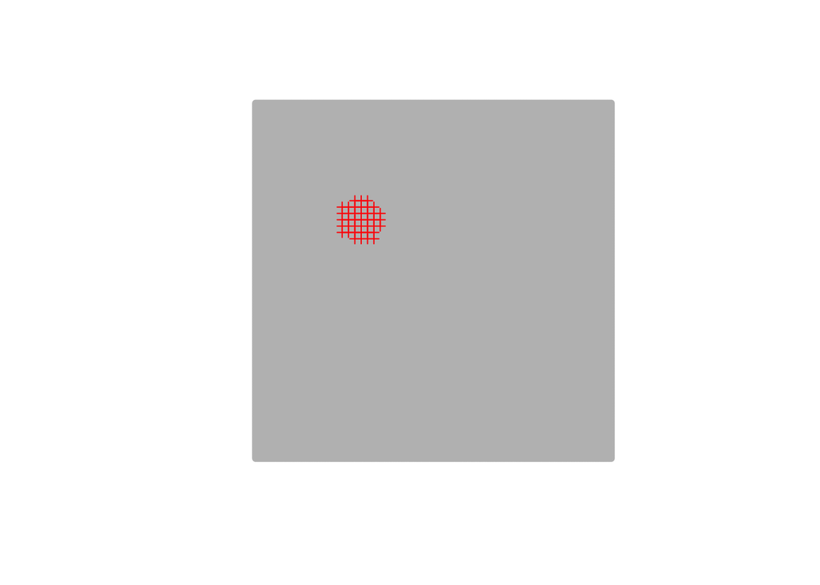

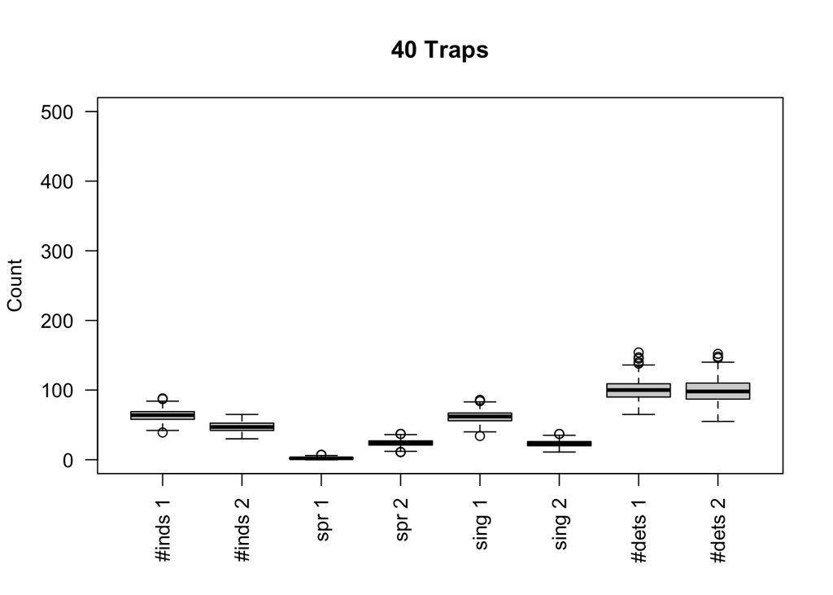

**120 Traps**

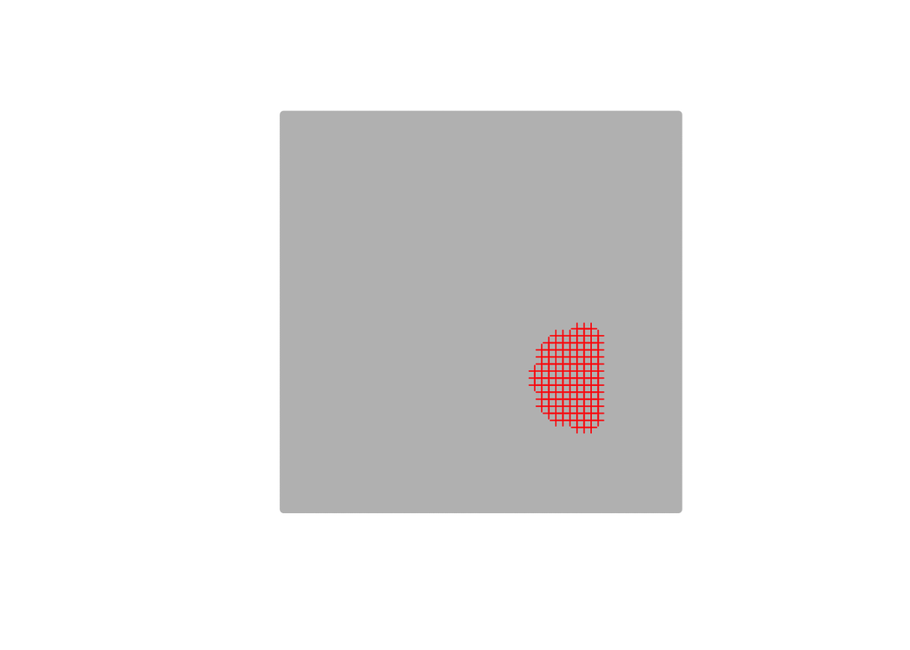

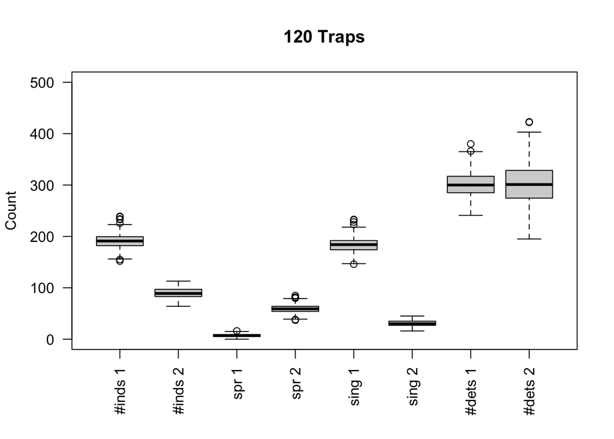

## Simulation Results

Sim Results from 800 m Grids (40 traps)

| Strata | D RB | D RSE | L0 RB | L0 RSE | Sigma RB | Sigma RSE | Reps |
| --- | --- | --- | --- | --- | --- | --- | --- |
| S1 | 10.1 | 0.315 | 1.3 | 0.208 | -1.9 | 0.125 | 487 |
| S2 | 12.8 | 0.470 | 0.0 | 0.194 | 4.9 | 0.358 | 414 |

Sim Results from 800 m Grids (120 traps)

| Strata | D RB | D RSE | L0 RB | L0 RSE | Sigma RB | Sigma RSE | Reps |
| --- | --- | --- | --- | --- | --- | --- | --- |
| S1 | 2.3 | 0.130 | 0.4 | 0.116 | -0.7 | 0.056 | 500 |
| S2 | 0.2 | 0.145 | -0.8 | 0.099 | 0.8 | 0.073 | 500 |

# Grids with optimal 2G spacing (700 m)

The optimal spacing used here is from extending the optimalSpacing function to two groups and optimising the sum of n and r across the two strata.

## Realisations and data summaries

**40 Traps**

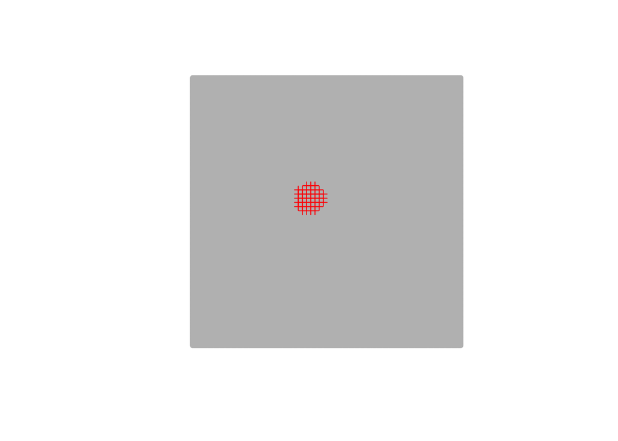

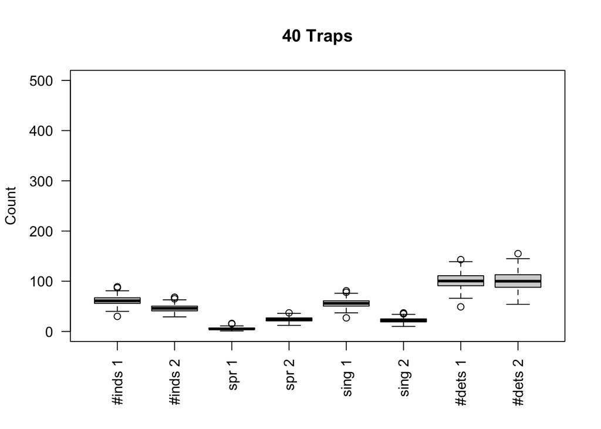

**120 Traps**

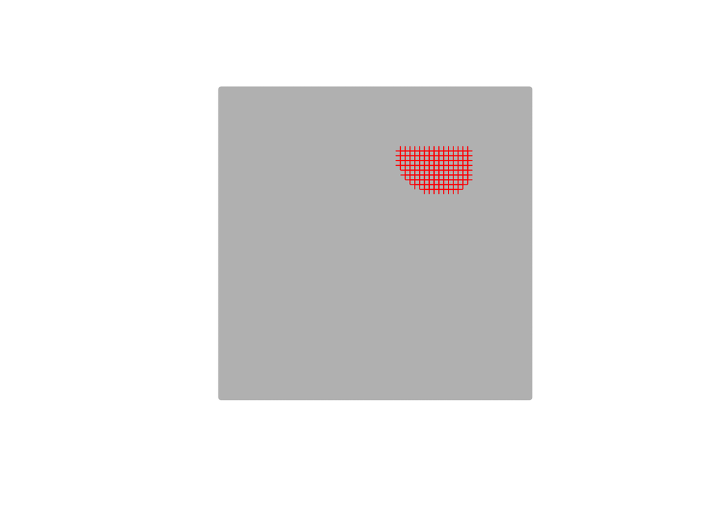

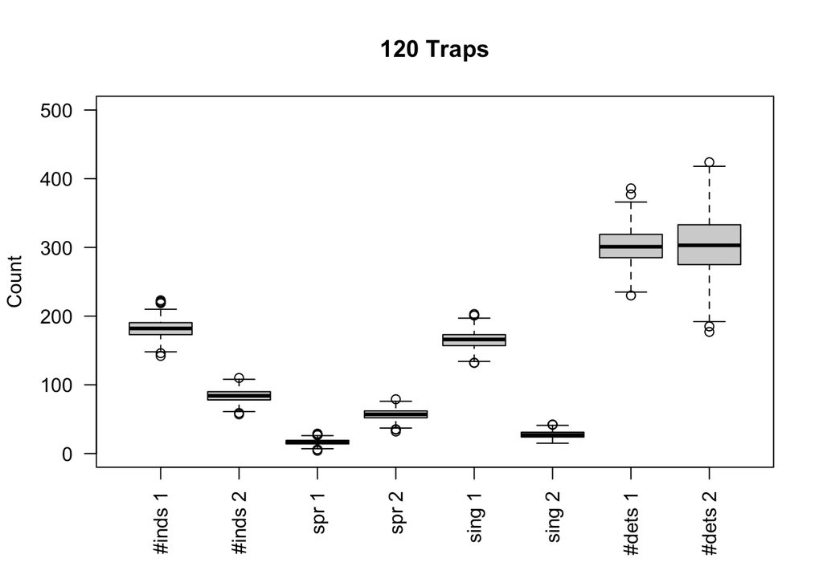

### Simulation Results

Sim Results from 700 m Grids (40 traps)

| Strata | D RB | D RSE | L0 RB | L0 RSE | Sigma RB | Sigma RSE | Reps |
| --- | --- | --- | --- | --- | --- | --- | --- |
| S1 | 3.0 | 0.179 | 0.7 | 0.208 | 0.0 | 0.079 | 500 |
| S2 | 12.9 | 0.534 | 3.7 | 0.203 | 7.9 | 0.397 | 417 |

Sim Results from 700 m Grids (120 traps)

| Strata | D RB | D RSE | L0 RB | L0 RSE | Sigma RB | Sigma RSE | Reps |
| --- | --- | --- | --- | --- | --- | --- | --- |
| S1 | 1.2 | 0.095 | 0.5 | 0.115 | -0.3 | 0.046 | 500 |
| S2 | 1.0 | 0.170 | 0.5 | 0.098 | 0.2 | 0.087 | 500 |

# Clustered Grid Designs

The clustered grids base within-cluster spacing on the smaller sigma and the between-cluster spacing on the larger sigma. Initially three different cluster configurations were tried and these two options were chosen:

1. 500 m / 1200 m: these spacings are based on optimal spacings for each sigma seperately
2. 400 m / 6000 m: these spacings are 2 * sigma for each strata

## Realisations and data summaries for optimal spacings (500 / 1200):

**40 Traps**

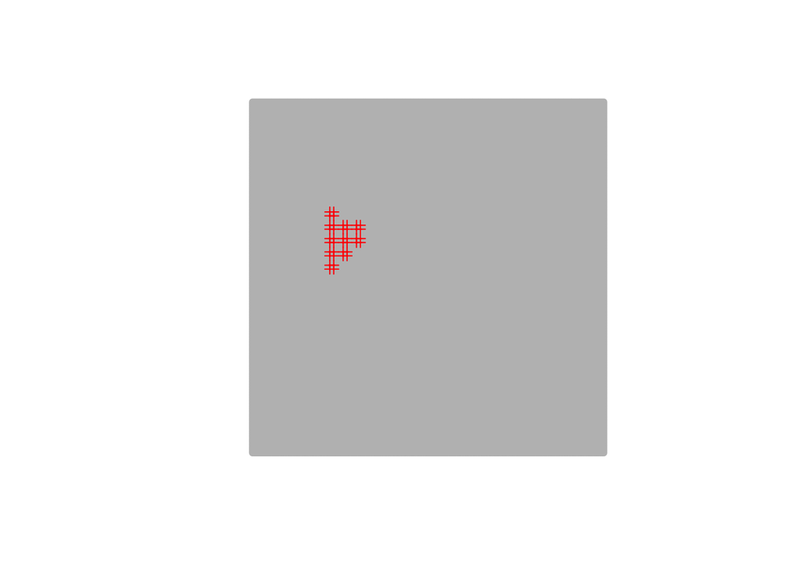

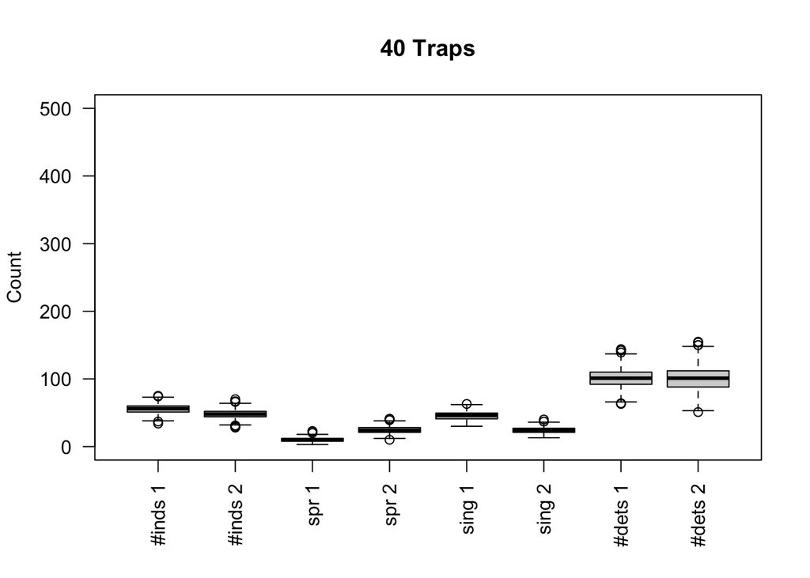

**120 Traps**

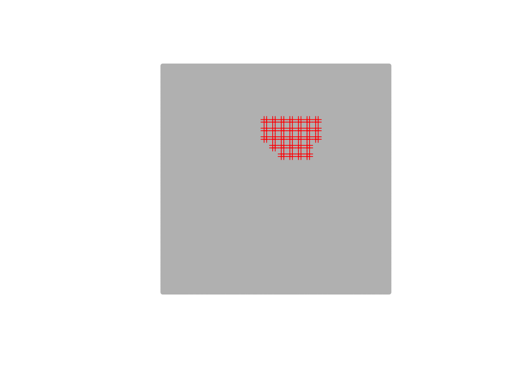

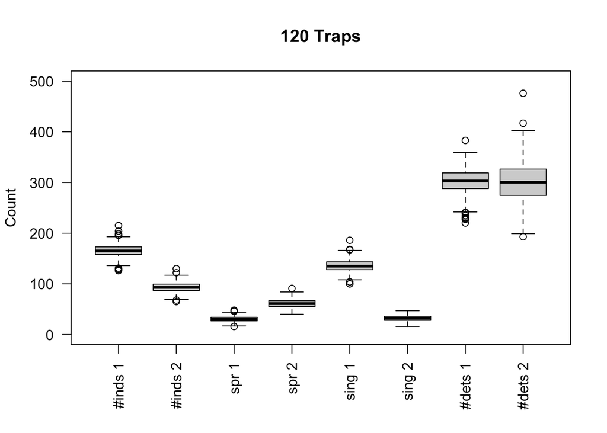

## Realisations and data summaries for 2 $\sigma$ spacings (400 / 6000):

**40 Traps**

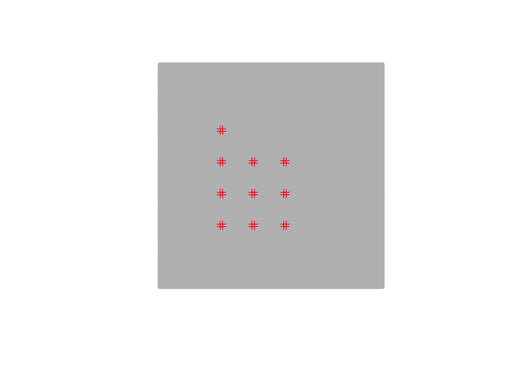

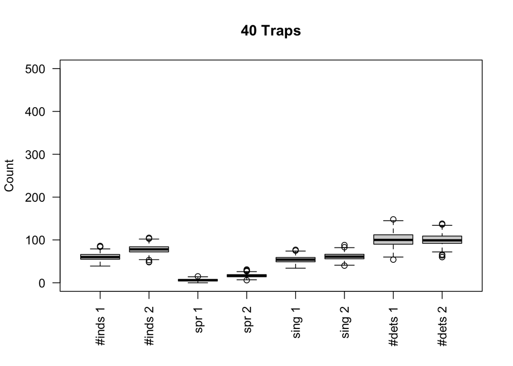

**120 Traps (actually only 64 traps!)**

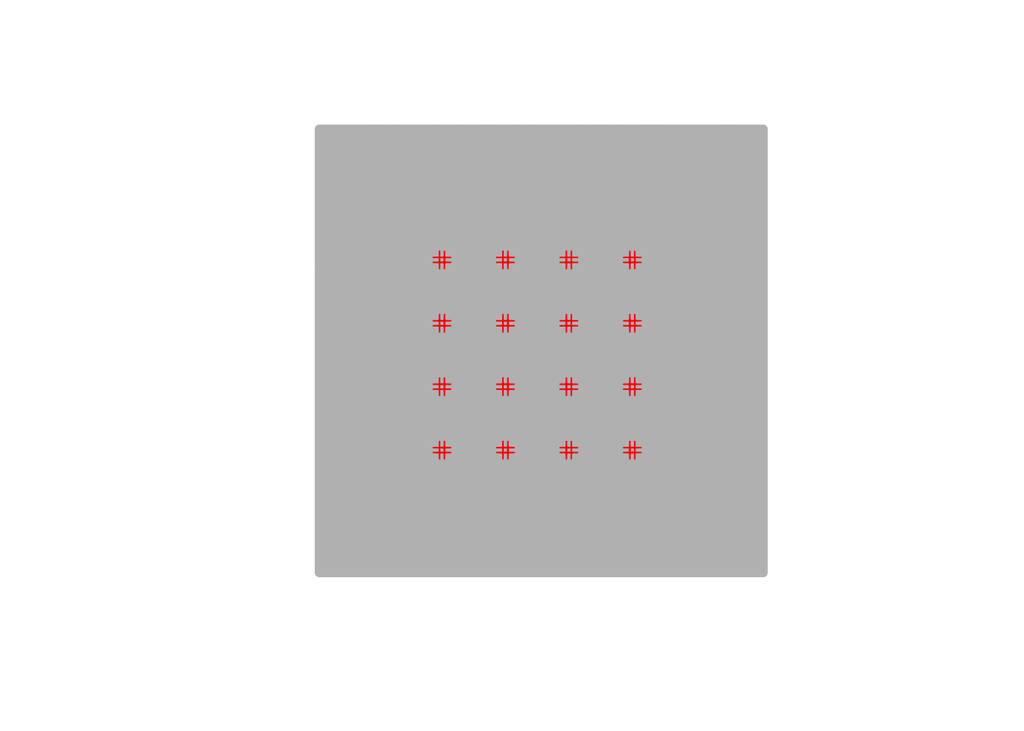

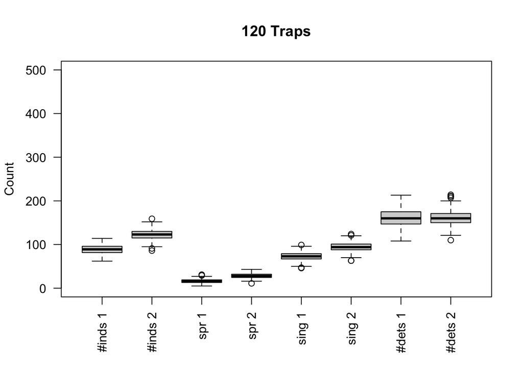

### Simulation Results

Sim Results from Clustered Grids (40 traps)

| Config | Strata | D RB | D RSE | L0 RB | L0 RSE | Sigma RB | Sigma RSE | Reps |
| --- | --- | --- | --- | --- | --- | --- | --- | --- |
| OS (2 g) | S1 | 3.9 | 0.186 | 1.0 | 0.198 | -0.4 | 0.109 | 500 |
|  | S2 | 8.8 | 0.449 | 2.8 | 0.205 | 5.9 | 0.353 | 482 |
| 2 sigma | S1 | 5.6 | 0.215 | 1.1 | 0.199 | -1.0 | 0.107 | 500 |
|  | S2 | 4.6 | 0.236 | 2.4 | 0.275 | 0.1 | 0.134 | 500 |

Sim Results from Clustered Grids (120 traps)

| Config | Strata | D RB | D RSE | L0 RB | L0 RSE | Sigma RB | Sigma RSE | Reps |
| --- | --- | --- | --- | --- | --- | --- | --- | --- |
| OS (2 g) | S1 | 0.7 | 0.115 | 0.5 | 0.110 | 0.0 | 0.062 | 500 |
|  | S2 | 1.0 | 0.141 | -0.5 | 0.097 | 0.1 | 0.072 | 500 |
| 2 sigma | S1 | 2.3 | 0.165 | 0.6 | 0.155 | 0.0 | 0.090 | 500 |
|  | S2 | 3.8 | 0.160 | -0.8 | 0.215 | 0.7 | 0.097 | 500 |

# GA4 Designs (min(n,r))

## Realisations and data summaries:

**Using S1 values:**

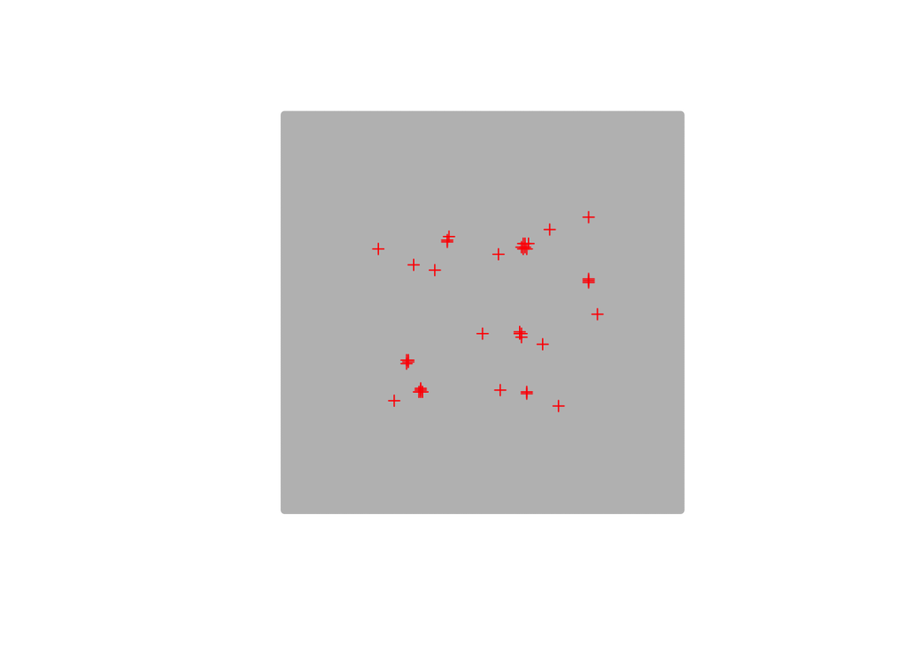

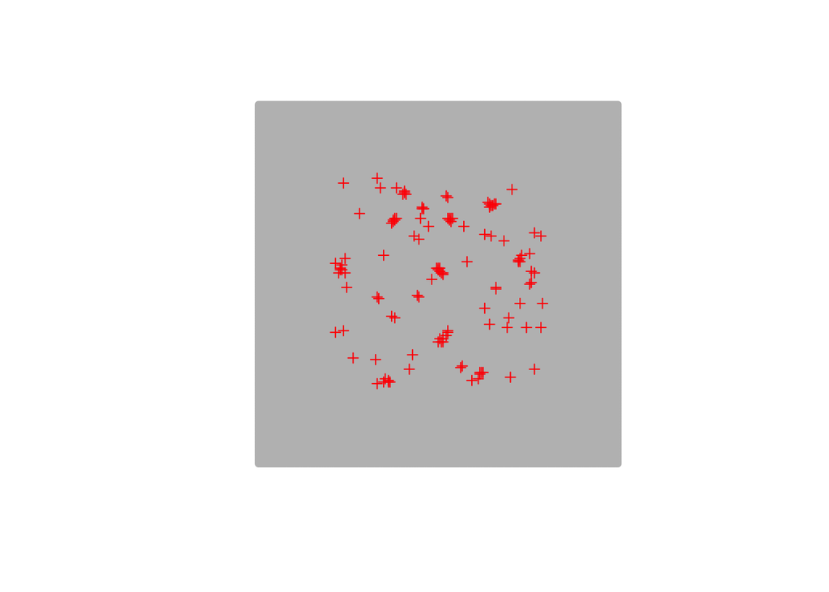

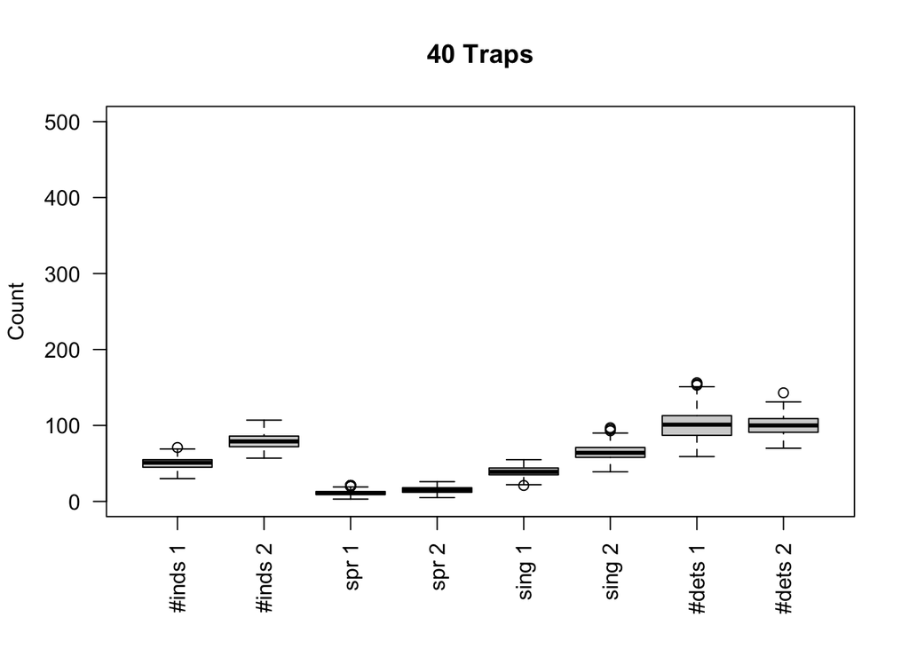

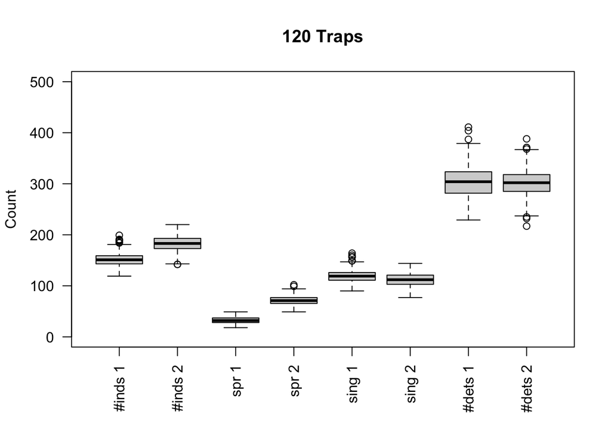

**Using S2 values:**

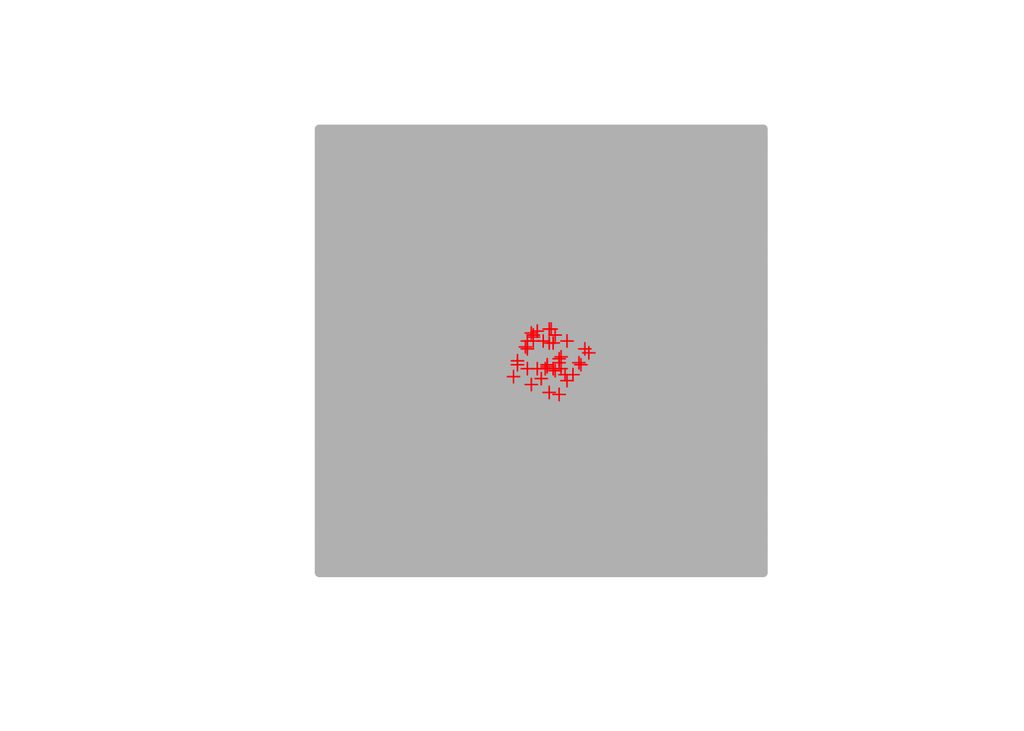

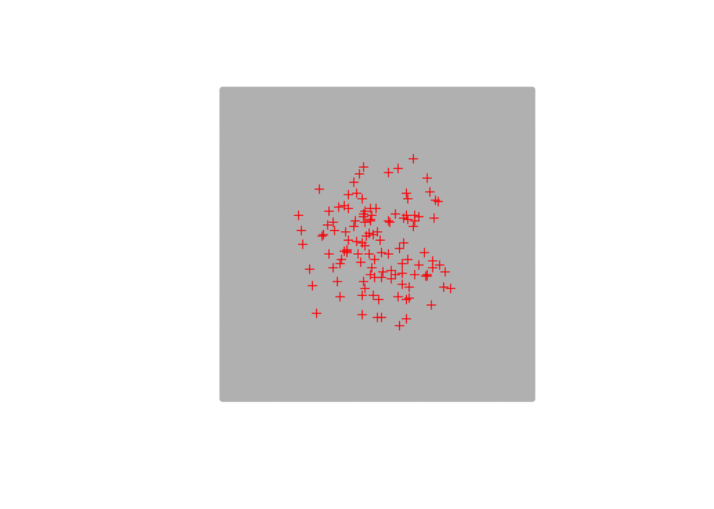

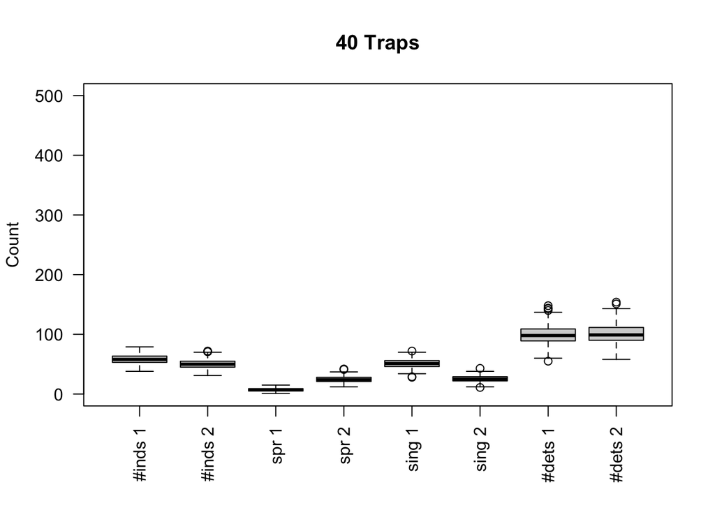

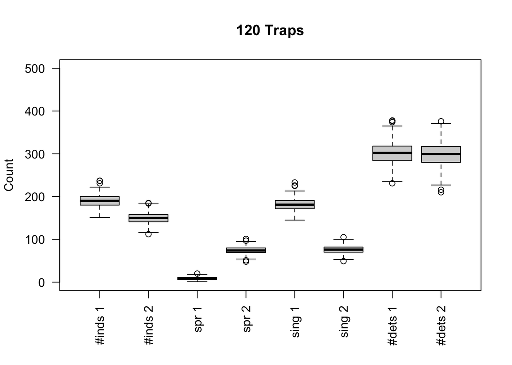

**Using Avg values:**

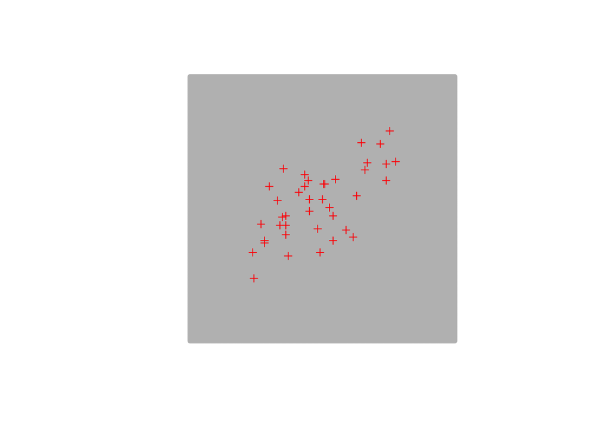

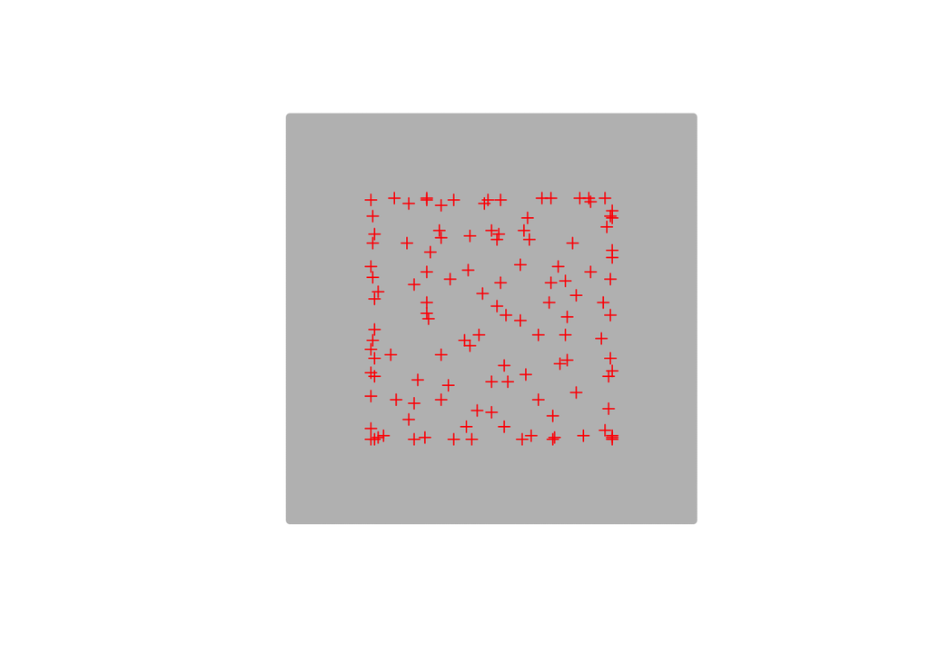

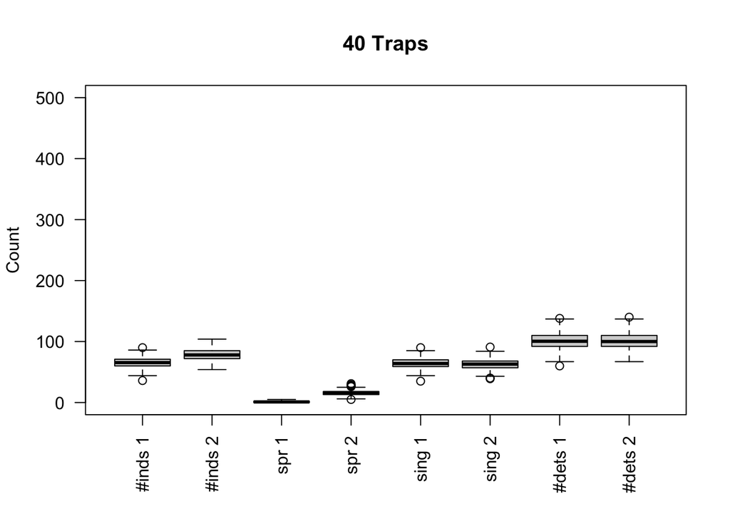

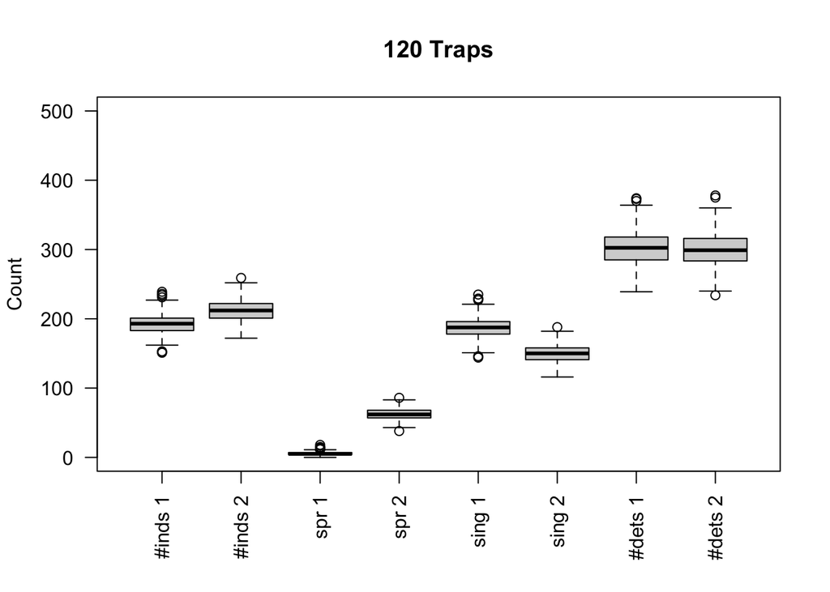

**Using Both values:**

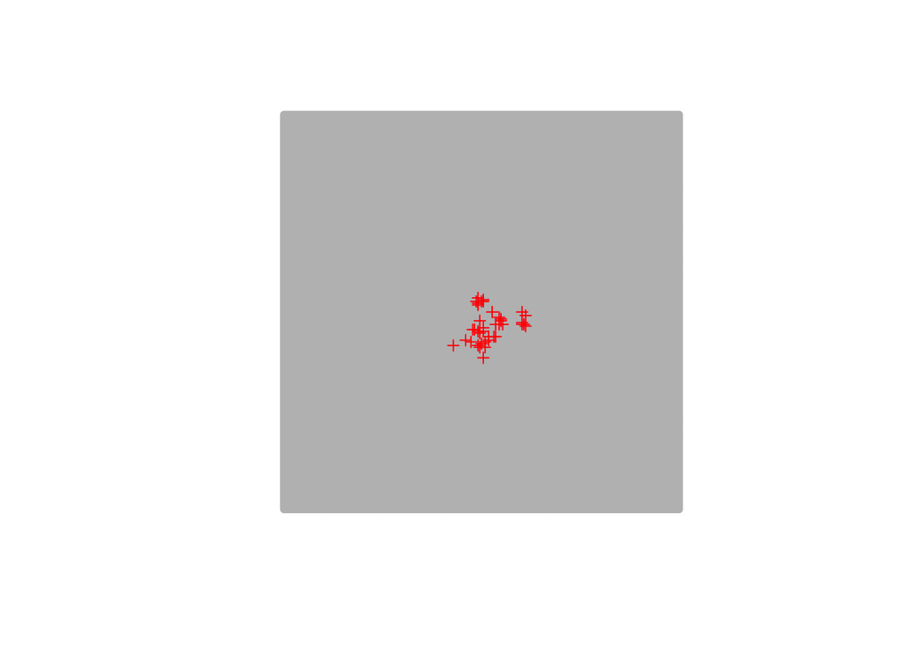

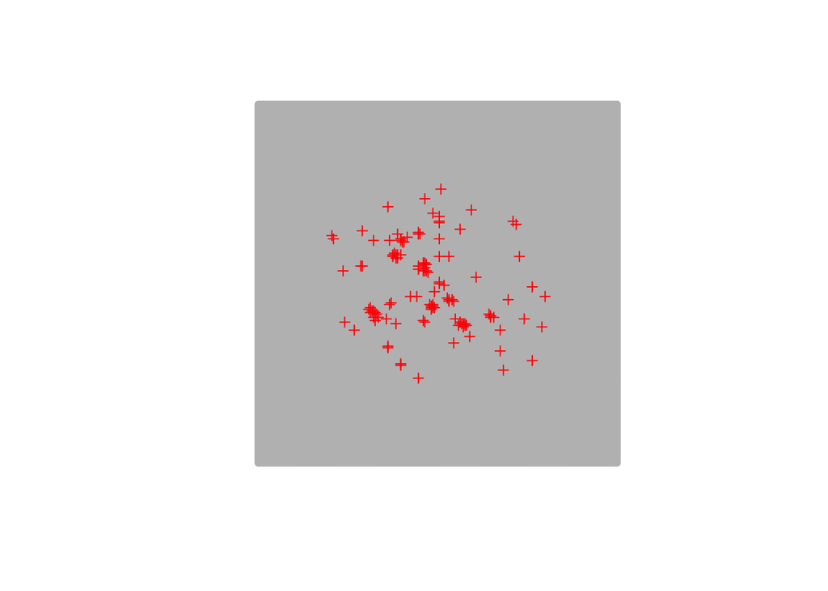

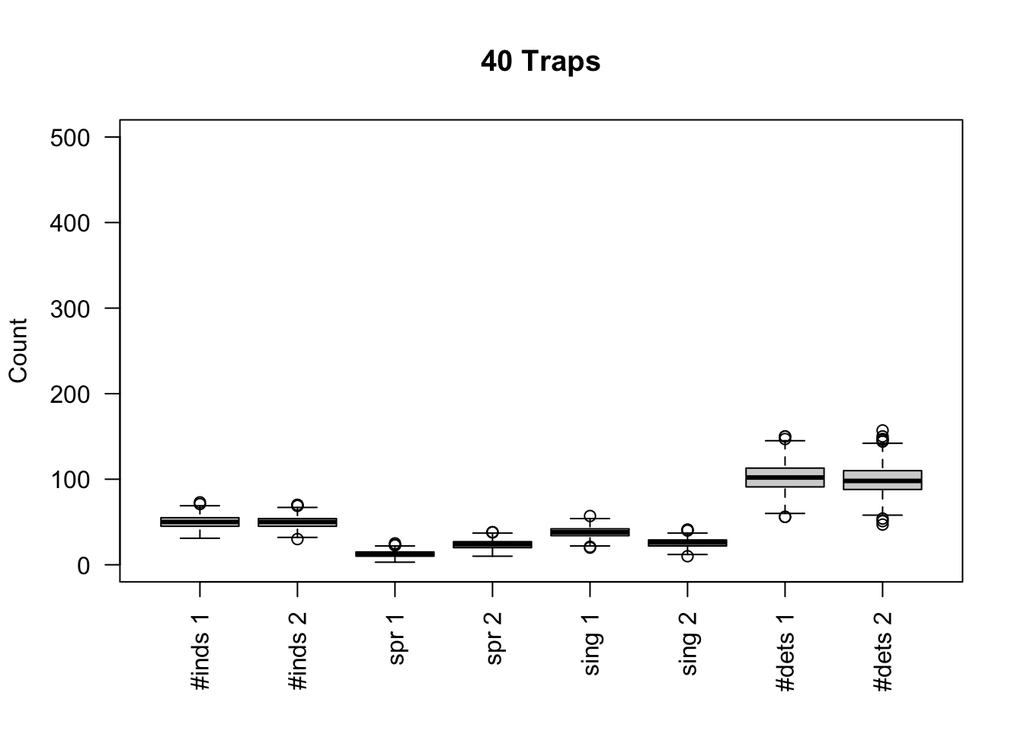

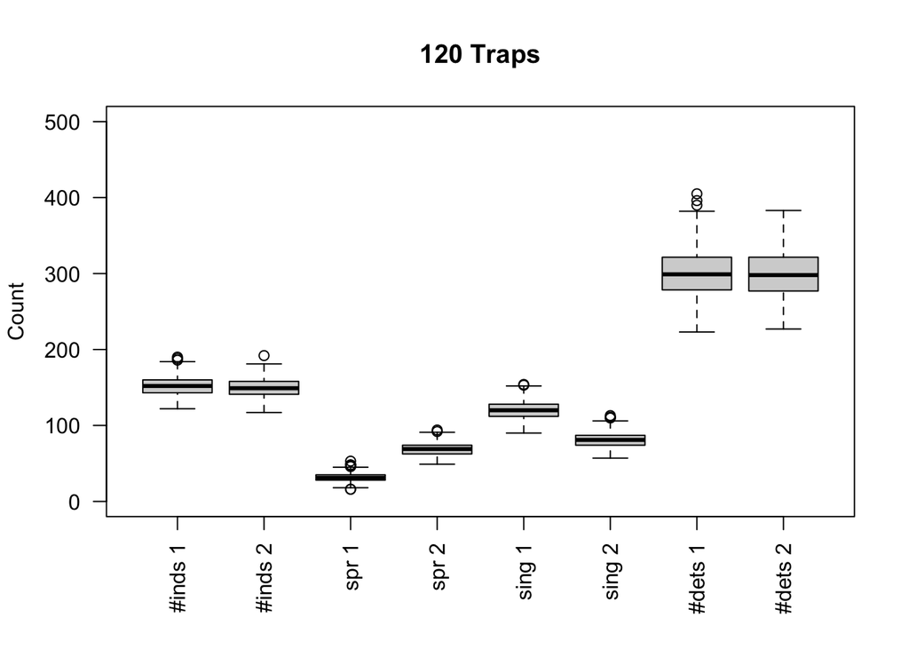

**Using Both (max-min) values:**